# The Gap-Closing Estimand

Replicating Lundberg (2024) manually

Author

Sam Harper

Published

September 9, 2026

## Overview

Lundberg (2024) introduces the **gap-closing estimand**: a way to ask *how much of an observed gap between social groups would close if we intervened on a treatment?* This document works through the mechanics using the package’s own simulated dataset — first calling `gapclosing()`, then replicating each step ‘by hand’.

The three manual estimators we cover are:

1. **Outcome model** (g-computation / standardization)
2. **Inverse probability weighting (IPW)**
3. **Doubly-robust (AIPW)**

```r
library(here)
library(gapclosing)
library(tidyverse)
library(tinytable)
library(marginaleffects)
library(ggdag)
library(dagitty)
library(ggraph)
```

## The causal model

Before touching data, we need to be explicit about the causal structure we assume. The DAG below encodes our assumptions:

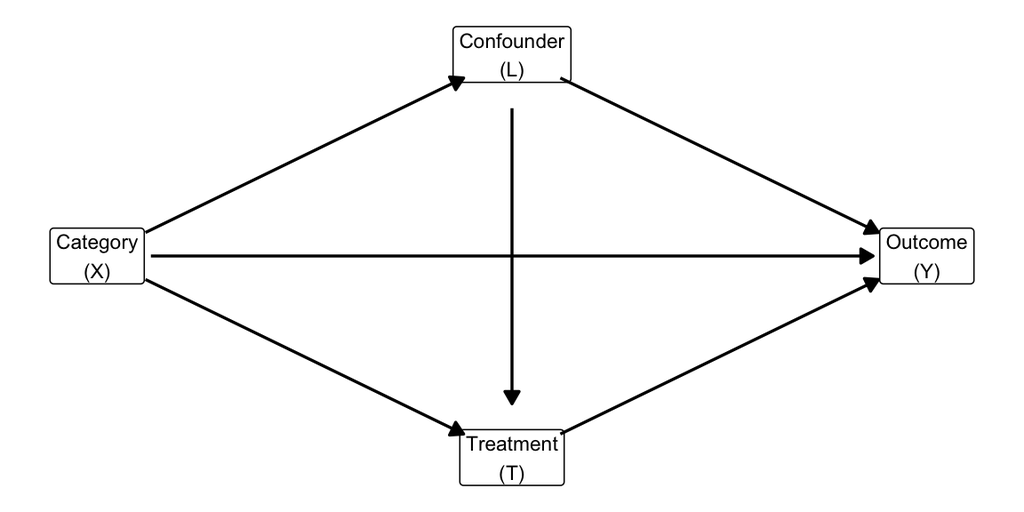

**Reading the DAG:**

- **X → L**: Category membership determines the distribution of the confounder (in the simulation, L’s mean shifts by −1.5 / 0 / +1.5 across categories A / B / C).
- **L → T**: The confounder raises treatment probability (p = plogis(L)), so higher-L groups are more likely to be treated.
- **L → Y**: The confounder also directly raises the outcome (Y = L + …), creating a backdoor path T ← L → Y.
- **T → Y**: The treatment effect of interest — and crucially, its magnitude *varies by category* (τ_A = +1.3, τ_B = 0, τ_C = −1.2).

The **backdoor path** T ← L → Y means a naive comparison of treated vs. untreated confounds the treatment effect with baseline L differences. Conditioning on L (within category) blocks this path and identifies E[Y(t)].

## The simulated data

The package ships a data-generating function. Here is exactly what it does:

```r
set.seed(08544)
n <- 1000

dat <- data.frame(
  category = sample(c("A", "B", "C"), n, replace = TRUE)
) |>
  mutate(
    # L | X ~ N(mu_X, 1);  mu differs by category
    confounder = rnorm(
      n,
      mean = case_when(category == "A" ~ -1.5,
                       category == "B" ~  0,
                       category == "C" ~  1.5),
      sd = 1
    ),
    # T | L ~ Bernoulli(plogis(L))  — L confounds T -> Y
    treatment = rbinom(n, 1, plogis(confounder)),
    # category-specific treatment effects
    tau = case_when(category == "A" ~  1.3,
                    category == "B" ~  0.0,
                    category == "C" ~ -1.2),
    # Y | L, T, X ~ N(L + T*tau_X, 1)
    outcome = rnorm(n,
      mean = confounder + treatment * tau,
      sd = 1)
  ) |>
  select(-tau)   # not observed in practice

head(dat)
```

```
  category confounder treatment    outcome
1        C   1.640509         1 -0.7970377
2        B   1.032373         0  1.9304909
3        C   2.217630         1 -0.2009803
4        A  -1.642914         0 -0.5015702
5        A  -1.844897         0 -1.2027025
6        A  -2.415100         0 -3.9288188
```

The key design features:

- **Confounding:** `confounder` (L) affects both treatment take-up (`plogis(L)`) and the outcome (`Y = L + ...`). Groups with higher L means (C > B > A) are both more likely to be treated *and* have higher baseline outcomes.
- **Effect heterogeneity:** τ is positive in A (+1.3), zero in B, and negative in C (−1.2). This means the *same* intervention (T=1) will *raise* outcomes in A but *lower* them in C.

## Step 1 — The gap

Before any counterfactual reasoning, what group differences do we actually observe?

```r
factual <- dat |>
  group_by(category) |>
  summarise(mean_y = mean(outcome), n = n(), .groups = "drop")

tt(factual, digits = 2)
```

| category | mean_y | n |
| --- | --- | --- |
| A | -1.091 | 343 |
| B | -0.038 | 332 |
| C | 0.495 | 325 |

```r
gap_AB_fact <- factual$mean_y[factual$category == "A"] -
               factual$mean_y[factual$category == "B"]
gap_CB_fact <- factual$mean_y[factual$category == "C"] -
               factual$mean_y[factual$category == "B"]

cat("Factual gap  A - B:", round(gap_AB_fact, 3),
    "\nFactual gap  C - B:", round(gap_CB_fact, 3), "\n")
```

```
Factual gap  A - B: -1.052
Factual gap  C - B: 0.534
```

These observed gaps conflate two things: (a) the effect of treatment and (b) differences in the confounder L across categories. Group C has the highest L mean, so its members get treated more often *and* have higher baseline outcomes — even though τ_C is actually negative.

## Step 2 — What are we actually estimating?

Before fitting any models it is worth being precise about the estimand, because the gap-closing estimand is easy to confuse with a treatment effect.

**What it is not.** A treatment effect contrast asks: for people in group $x$, how much does treatment help?

$$E[Y(1) \mid X=x] - E[Y(0) \mid X=x] \quad \text{(ATE within category)}$$

**What it is.** The gap-closing estimand asks: after a common intervention that sets $T=1$ for everyone, how much inequality *between* groups remains?

$$E[Y(1) \mid X=A] - E[Y(1) \mid X=B] \quad \text{(gap-closing estimand)}$$

The comparison is *across groups under a shared counterfactual*, not *across treatment arms within a group*. You hold the treatment fixed at $T=1$ for everyone and ask how the outcome means still differ by category.

The connection to the factual gap is what makes this useful for health equity work. Start with the observed gap:

$$\underbrace{E[Y \mid X=A] - E[Y \mid X=B]}_{\text{factual gap}}$$

This conflates differential treatment rates, confounder differences, and treatment effect heterogeneity. The gap-closing estimand isolates one specific mechanism: *if we equalized treatment uptake at $T=1$, what share of that gap would close?*

The answer need not be “most of it.” In this simulation the gap nearly closes because it is almost entirely driven by differential treatment rates (through L). But equalizing treatment could leave most of the gap intact — if the gap is driven by something treatment does not touch — which is itself a substantive finding.

## Step 3 — The `gapclosing()` function

**Counterfactual intervention:** set T = 1 for everyone.

The `gapclosing()` function fits an outcome model and a propensity model, combines them in a doubly-robust estimator, and returns the counterfactual mean for each category.

```r
estimate <- gapclosing(
  data                     = dat,
  counterfactual_assignments = 1,
  outcome_formula          = formula(outcome ~ confounder + category * treatment),
  treatment_formula        = formula(treatment ~ confounder + category),
  category_name            = "category",
  se                       = FALSE
)

summary(estimate)
```

```
Gap-closing estimates using doubly_robust estimation on one sample.

Treatment model was glm estimation with model formula:
formula(treatment ~ confounder + category)

Outcome model was lm estimation with model formula:
formula(outcome ~ confounder + category * treatment)

Factual estimates are means within and disparities across category.
Counterfactual estimates are under an intervention to set  to 1.

Factual mean outcomes:
# A tibble: 3 × 2
  category estimate
  <chr>       <dbl>
1 A         -1.09
2 B         -0.0384
3 C          0.495

Counterfactual mean outcomes (post-intervention means):
# A tibble: 3 × 2
  category estimate
  <chr>       <dbl>
1 A         -0.102
2 B          0.0409
3 C          0.0805

Factual disparities:
# A tibble: 6 × 2
  category estimate
  <chr>       <dbl>
1 A - B      -1.05
2 A - C      -1.59
3 B - A       1.05
4 B - C      -0.534
5 C - A       1.59
6 C - B       0.534

Counterfactual disparities (gap-closing estimands):
# A tibble: 6 × 2
```

[output cut: 17 more lines]

[output not shown]

Now let’s recreate those numbers ourselves.

## Step 4 — By hand

The identification assumption throughout is **no unmeasured confounding** given (category, confounder):

$$Y(t) \perp\!\!\!\perp T \mid \{\text{category},\, L\}$$

Because we generated the data, we know this holds by construction.

### 3a. Outcome model (standardization)

**Logic:** fit an outcome model on the observed data, then predict every person’s outcome *as if* they had been treated (T = 1), and average within each category. This “standardizes” over the confounder distribution.

$$\hat{E}[Y(1) \mid X = x] = \frac{1}{n_x} \sum_{i: X_i = x} \hat{E}[Y \mid L_i, X_i, T = 1]$$

```r
# Fit outcome model
m_out <- lm(outcome ~ confounder + category * treatment, data = dat)

# Predict Y(T=1) for every person
dat_t1  <- dat |> mutate(treatment = 1)
dat$yhat_t1 <- predict(m_out, newdata = dat_t1)

# Average within category
cf_om <- dat |>
  group_by(category) |>
  summarise(cf_mean_om = mean(yhat_t1), .groups = "drop")

tt(cf_om, digits = 2)
```

| category | cf_mean_om |
| --- | --- |
| A | 0.049 |
| B | -0.037 |
| C | 0.132 |

This can also be accomplished with `marginaleffects`, but it takes some care in estimating. Using the `var` option with `datagrid=1` set the entire sample to a specific category then generates predictions and averages them:

```r
cf_om_mp <- avg_predictions(m_out,
  var = "category",
  datagrid(treatment=1)) |>
  select(category, estimate, conf.low, conf.high)

tt(cf_om_mp, digits = 2)
```

| category | estimate | conf.low | conf.high |
| --- | --- | --- | --- |
| A | 1.372 | 1.14 | 1.6 |
| B | -0.011 | -0.17 | 0.15 |
| C | -1.291 | -1.46 | -1.12 |

What we want, in fact, is specific predictions within each category while setting the treatment indicator to 1 for everyone, regardless of their actual treatment status:

```r
tt(cf_om_mp, digits = 2)
```

| category | estimate | conf.low | conf.high |
| --- | --- | --- | --- |
| A | 1.372 | 1.14 | 1.6 |
| B | -0.011 | -0.17 | 0.15 |
| C | -1.291 | -1.46 | -1.12 |

```r
cf_om_mp2 <- avg_predictions(m_out,
  by = "category",
  newdata = transform(dat, treatment = 1)) |>
  select(category, estimate, conf.low, conf.high)

tt(cf_om_mp2, digits = 2)
```

| category | estimate | conf.low | conf.high |
| --- | --- | --- | --- |
| A | 0.049 | -0.1832 | 0.28 |
| B | -0.037 | -0.1933 | 0.12 |
| C | 0.132 | 0.0028 | 0.26 |

The outcome model is consistent when the outcome model is correctly specified. It can fail if the model is misspecified (wrong functional form, missing interactions).

### 3b. Inverse probability weighting (IPW)

**Logic:** reweight treated observations so that, within each category, the treated look like a random draw from the full population. Treated people with a low propensity (lucky to be treated) get upweighted; those with a high propensity get downweighted.

We use the **Hajek (stabilized) estimator** to keep weights well-behaved:

$$\hat{E}[Y(1) \mid X = x] = \frac{\sum_{i: X_i = x} \frac{T_i Y_i}{\hat{p}_i}}{\sum_{i: X_i = x} \frac{T_i}{\hat{p}_i}}$$

where $\hat{p}_i = \hat{P}(T = 1 \mid L_i, X_i)$.

```r
# Fit propensity model
m_ps  <- glm(treatment ~ confounder + category,
             data = dat, family = binomial)
dat$ps <- predict(m_ps, type = "response")

# Hajek IPW estimator within each category
cf_ipw <- dat |>
  group_by(category) |>
  summarise(
    cf_mean_ipw = sum(treatment * outcome / ps) /
                  sum(treatment / ps),
    .groups = "drop"
  )

cf_ipw
```

```
# A tibble: 3 × 2
  category cf_mean_ipw
  <chr>          <dbl>
1 A             0.0527
2 B             0.0853
3 C             0.0164
```

IPW is consistent when the propensity model is correctly specified. It can be noisy when propensity scores are near 0 or 1 (extreme weights).

### 3c. Doubly-robust (AIPW)

**Logic:** combine both models so that you only need *one* of them to be correct. The AIPW pseudo-outcome for person $i$ is:

$$\psi_i = \underbrace{\hat{E}[Y \mid L_i, X_i, T=1]}_{\text{outcome model prediction}} + \underbrace{\frac{T_i}{\hat{p}_i}\bigl(Y_i - \hat{E}[Y \mid L_i, X_i, T=1]\bigr)}_{\text{IPW residual correction}}$$

Then $\hat{E}[Y(1) \mid X = x] = \bar{\psi}$ within category $x$.

When the outcome model is correct, the second term has mean zero — it’s just noise that washes out. When the propensity model is correct, the IPW term corrects any bias from outcome model misspecification.

```r
dat <- dat |>
  mutate(
    psi = yhat_t1 + (treatment / ps) * (outcome - yhat_t1)
  )

cf_dr <- dat |>
  group_by(category) |>
  summarise(cf_mean_dr = mean(psi), .groups = "drop")

cf_dr
```

```
# A tibble: 3 × 2
  category cf_mean_dr
  <chr>         <dbl>
1 A           -0.0910
2 B            0.0394
3 C            0.0795
```

## Step 5 — Compare all estimators

```r
results <- factual |>
  rename(factual = mean_y) |>
  select(category, factual) |>
  left_join(cf_om,  by = "category") |>
  left_join(cf_ipw, by = "category") |>
  left_join(cf_dr,  by = "category")

results
```

```
# A tibble: 3 × 5
  category factual cf_mean_om cf_mean_ipw cf_mean_dr
  <chr>      <dbl>      <dbl>       <dbl>      <dbl>
1 A        -1.09       0.0488      0.0527    -0.0910
2 B        -0.0384    -0.0370      0.0853     0.0394
3 C         0.495      0.132       0.0164     0.0795
```

### Gap-closing fractions

How much of the factual gap (relative to category B) would close under universal treatment?

```r
gcf <- function(cf_col) {
  cf <- results[[cf_col]]
  names(cf) <- results$category
  gap_cf <- cf["A"] - cf["B"]
  gap_f  <- results$factual[results$category == "A"] -
            results$factual[results$category == "B"]
  1 - gap_cf / gap_f
}

tibble(
  Estimator       = c("Outcome model", "IPW", "Doubly-robust"),
  `Gap A-B closed` = map_dbl(c("cf_mean_om","cf_mean_ipw","cf_mean_dr"), gcf)
)
```

```
# A tibble: 3 × 2
  Estimator     `Gap A-B closed`
  <chr>                    <dbl>
1 Outcome model            1.08
2 IPW                      0.969
3 Doubly-robust            0.876
```

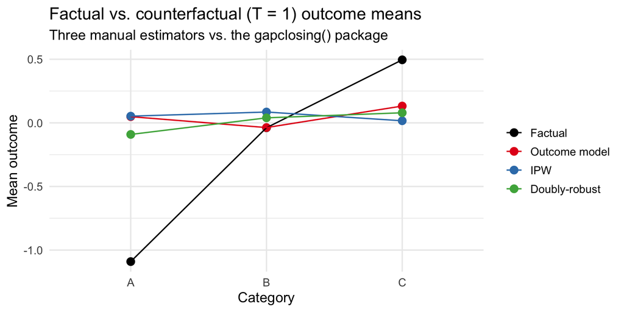

```r
plot_df <- results |>
  pivot_longer(-category, names_to = "estimator", values_to = "mean") |>
  mutate(estimator = recode(estimator,
    factual     = "Factual",
    cf_mean_om  = "Outcome model",
    cf_mean_ipw = "IPW",
    cf_mean_dr  = "Doubly-robust"
  ) |> factor(levels = c("Factual","Outcome model","IPW","Doubly-robust")))

ggplot(plot_df, aes(x = category, y = mean,
                    color = estimator, group = estimator)) +
  geom_point(size = 3) +
  geom_line() +
  scale_color_manual(values = c("black","#E41A1C","#377EB8","#4DAF4A")) +
  labs(
    x = "Category", y = "Mean outcome", color = NULL,
    title = "Factual vs. counterfactual (T = 1) outcome means",
    subtitle = "Three manual estimators vs. the gapclosing() package"
  ) +
  theme_minimal(base_size = 13)
```

## Key takeaways

1. **The factual gap is confounded.** Category C has the highest observed mean despite having a *negative* treatment effect (τ_C = −1.2), because C members have the highest baseline L.
2. **Universal treatment (T = 1) nearly equalizes outcomes** across categories. The outcome model, IPW, and doubly-robust estimators all agree: the counterfactual means cluster much closer together than the factual means.
3. **All three estimators agree here** because both the outcome model and the propensity model are correctly specified (we generated the data). In practice, the doubly-robust estimator is preferred because it only needs one of the two models to be right.
4. **The gap-closing fraction** tells you what share of the observed gap a given intervention would eliminate — a more policy-relevant quantity than the raw treatment effect.

## References

Lundberg, Ian. 2024. “The Gap-Closing Estimand: A Causal Approach to Study Interventions That Close Disparities Across Social Categories.” *Sociological Methods & Research* 53 (2): 507–70. https://doi.org/10.1177/00491241211055769.